# hw4_Adam_Banwell

Adam Banwell

10/11/2021

## Part one: Cleaning data

```r
library(dplyr)
```

```r
library(ggplot2)

library(readxl)
defense <- read_excel('cyclonesFootball2020.xlsx', sheet='Defensive')
defense
```

```
## # A tibble: 372 x 11
##    Name       Opponent_Oppone~ Tackles_Solo Tackles_ASST Tackles_TFL Tackles_Sack
##    <chr>      <chr>            <chr>        <chr>        <chr>       <chr>
##  1 Rose, Mike Louisiana        2            4            1.0         0
##  2 Rose, Mike TCU              6            4            0           0
##  3 Rose, Mike Oklahoma         6            5            1.5         0.5
##  4 Rose, Mike Texas Tech       3            0            1.0         0
##  5 Rose, Mike Oklahoma St.     7            3            1.0         0
##  6 Rose, Mike Kansas           4            1            0           0
##  7 Rose, Mike Baylor           7            4            1.5         0
##  8 Rose, Mike Kansas State     4            3            2.5         1.0
##  9 Rose, Mike Texas            4            9            1.5         0
## 10 Rose, Mike West Virginia    2            3            0           0
## # ... with 362 more rows, and 5 more variables: Turnover_FF <chr>,
## #   Turnover_FR <chr>, Turnover_INT <chr>, Pass_QBH <chr>, Pass_PB <chr>
```

```r
str(defense)
```

```
## tibble [372 x 11] (S3: tbl_df/tbl/data.frame)
##  $ Name             : chr [1:372] "Rose, Mike" "Rose, Mike" "Rose, Mike" "Rose, Mike" ...
##  $ Opponent_Opponent: chr [1:372] "Louisiana" "TCU" "Oklahoma" "Texas Tech" ...
##  $ Tackles_Solo     : chr [1:372] "2" "6" "6" "3" ...
##  $ Tackles_ASST     : chr [1:372] "4" "4" "5" "0" ...
##  $ Tackles_TFL      : chr [1:372] "1.0" "0" "1.5" "1.0" ...
##  $ Tackles_Sack     : chr [1:372] "0" "0" "0.5" "0" ...
##  $ Turnover_FF      : chr [1:372] "0" "0" "0" "0" ...
##  $ Turnover_FR      : chr [1:372] "0" "0" "0" "0" ...
##  $ Turnover_INT     : chr [1:372] "0" "1" "0" "0" ...
##  $ Pass_QBH         : chr [1:372] "0" "0" "1" "0" ...
##  $ Pass_PB          : chr [1:372] "0" "0" "0" "0" ...
```

```r
offense <- read_excel('cyclonesFootball2020.xlsx', sheet='Offensive')
offense
```

```
## # A tibble: 156 x 12
##    Name          Opponent_Oppone~ Receiving_REC Receiving_YDS Receiving_TD Rushing_ATT
##    <chr>         <chr>            <chr>         <chr>         <chr>        <chr>
##  1 Akers, Landen Louisiana        0             0             0            <NA>
##  2 Akers, Landen TCU              2             60            0            <NA>
##  3 Akers, Landen Oklahoma         1             35            0            <NA>
##  4 Akers, Landen Texas Tech       4             34            0            <NA>
##  5 Akers, Landen Oklahoma St.     0             0             0            <NA>
##  6 Akers, Landen Kansas           6             76            0            <NA>
##  7 Akers, Landen Baylor           1             11            0            <NA>
##  8 Akers, Landen Kansas State     0             0             0            <NA>
##  9 Akers, Landen Texas            1             10            0            <NA>
## 10 Akers, Landen West Virginia    1             2             1            <NA>
## # ... with 146 more rows, and 6 more variables: Rushing_YDS <chr>,
## #   Rushing_TD <chr>, Passing_CMP-ATT <chr>, Passing_YDS <chr>,
## #   Passing_TD <chr>, Passing_INT <chr>
```

```r
str(offense)
```

```
## tibble [156 x 12] (S3: tbl_df/tbl/data.frame)
##  $ Name             : chr [1:156] "Akers, Landen" "Akers, Landen" "Akers, Landen" "Akers, Landen" ...
##  $ Opponent_Opponent: chr [1:156] "Louisiana" "TCU" "Oklahoma" "Texas Tech" ...
##  $ Receiving_REC    : chr [1:156] "0" "2" "1" "4" ...
##  $ Receiving_YDS    : chr [1:156] "0" "60" "35" "34" ...
##  $ Receiving_TD     : chr [1:156] "0" "0" "0" "0" ...
##  $ Rushing_ATT      : chr [1:156] NA NA NA NA ...
##  $ Rushing_YDS      : chr [1:156] NA NA NA NA ...
##  $ Rushing_TD       : chr [1:156] NA NA NA NA ...
##  $ Passing_CMP-ATT  : chr [1:156] NA NA NA NA ...
##  $ Passing_YDS      : chr [1:156] NA NA NA NA ...
##  $ Passing_TD       : chr [1:156] NA NA NA NA ...
##  $ Passing_INT      : chr [1:156] NA NA NA NA ...
```

```r
biography <- read_excel('cyclonesFootball2020.xlsx', sheet='Biography')
biography
```

```
## # A tibble: 116 x 7
##    Name                 Position       Height Weight Class  Hometown  Highschool
##    <chr>                <chr>          <chr>  <chr>  <chr>  <chr>     <chr>
##  1 Akers, Landen        Wide Receiver  6-0    191    Redsh~ Cedar Ra~ Washington
##  2 Allen, Chase         Tight End      6-7    240    Redsh~ Nixa, Mo. Nixa
##  3 Anderson, Ezeriah    Wide Receiver  6-5    208    Redsh~ Seffner,~ Armwood
##  4 Antoine Jr. , Michal Defensive Back 6-0    180    Fresh~ Ft. Laud~ Cardinal ~
##  5 Assalley, Connor     Placekicker    6-0    195    Redsh~ Napervil~ Central
##  6 Azunna, Arnold       Defensive Back 6-0    199    Redsh~ Grand Pr~ Lake Ridge
##  7 Bailey, Cordarrius   Defensive End  6-3    253    Redsh~ Clarksda~ Clarksdale
##  8 Bailey, JaQuan       Defensive End  6-2    261    Redsh~ Jacksonv~ Raines
##  9 Bailey, Joshua       Defensive Line 6-2    288    Redsh~ Jacksonv~ Raines
## 10 Bitter, Aidan        Wide Receiver  6-2    182    Fresh~ Tampa, F~ Steinbren~
## # ... with 106 more rows
```

```r
str(biography)
```

```
## tibble [116 x 7] (S3: tbl_df/tbl/data.frame)
##  $ Name      : chr [1:116] "Akers, Landen" "Allen, Chase" "Anderson, Ezeriah" "Antoine Jr. , Michal" ...
##  $ Position  : chr [1:116] "Wide Receiver" "Tight End" "Wide Receiver" "Defensive Back" ...
##  $ Height    : chr [1:116] "6-0" "6-7" "6-5" "6-0" ...
##  $ Weight    : chr [1:116] "191" "240" "208" "180" ...
##  $ Class     : chr [1:116] "Redshirt Senior" "Redshirt Senior" "Redshirt Freshman" "Freshman" ...
##  $ Hometown  : chr [1:116] "Cedar Rapids, Iowa" "Nixa, Mo." "Seffner, Fla." "Ft. Lauderdale, Fla." ...
##  $ Highschool: chr [1:116] "Washington" "Nixa" "Armwood" "Cardinal Gibbons" ...
```

#1. player names and opponent names should be factors.

```r
defense$Name = factor(defense$Name)
defense$Opponent_Opponent = factor(defense$Opponent_Opponent)

offense$Name = factor(offense$Name)
offense$Opponent_Opponent = factor(offense$Opponent_Opponent)

biography$Name = factor(biography$Name)
```

#2. All offensive and defensive statistics should be numerical. The Weight column in biogrpahy should also be numeric.

```r
defClean = defense %>% select(-Name, -Opponent_Opponent) %>% mutate_if(is.character,as.numeric)
defClean = defense %>% select(Name, Opponent_Opponent) %>% mutate(defClean)
defClean
```

```
## # A tibble: 372 x 11
##    Name       Opponent_Oppone~ Tackles_Solo Tackles_ASST Tackles_TFL Tackles_Sack
##    <fct>      <fct>                   <dbl>        <dbl>       <dbl>        <dbl>
##  1 Rose, Mike Louisiana                   2            4         1            0
##  2 Rose, Mike TCU                         6            4         0            0
##  3 Rose, Mike Oklahoma                    6            5         1.5          0.5
##  4 Rose, Mike Texas Tech                  3            0         1            0
##  5 Rose, Mike Oklahoma St.                7            3         1            0
##  6 Rose, Mike Kansas                      4            1         0            0
##  7 Rose, Mike Baylor                      7            4         1.5          0
##  8 Rose, Mike Kansas State                4            3         2.5          1
##  9 Rose, Mike Texas                       4            9         1.5          0
## 10 Rose, Mike West Virginia               2            3         0            0
## # ... with 362 more rows, and 5 more variables: Turnover_FF <dbl>,
## #   Turnover_FR <dbl>, Turnover_INT <dbl>, Pass_QBH <dbl>, Pass_PB <dbl>
```

```r
#Replace Pass cmp-att with two seperate columns
offClean = offense %>% mutate(Passing_CMP = substring(offense$"Passing_CMP-ATT", 1,2))
offClean = offClean %>% mutate(Passing_ATT = substring(offense$"Passing_CMP-ATT", 57))

offclean = offClean %>% select(-"Passing_CMP-ATT")

offClean2 = offclean %>% select(-Name, -Opponent_Opponent) %>% mutate_if(is.character,as.numeric)
offClean = offClean %>% select(Name, Opponent_Opponent) %>% mutate(offClean2)
offClean
```

```
## # A tibble: 156 x 13
##    Name          Opponent_Oppone~ Receiving_REC Receiving_YDS Receiving_TD Rushing_ATT
##    <fct>         <fct>                    <dbl>         <dbl>        <dbl>       <dbl>
##  1 Akers, Landen Louisiana                    0             0            0          NA
##  2 Akers, Landen TCU                          2            60            0          NA
##  3 Akers, Landen Oklahoma                     1            35            0          NA
##  4 Akers, Landen Texas Tech                   4            34            0          NA
##  5 Akers, Landen Oklahoma St.                 0             0            0          NA
##  6 Akers, Landen Kansas                       6            76            0          NA
##  7 Akers, Landen Baylor                       1            11            0          NA
##  8 Akers, Landen Kansas State                 0             0            0          NA
##  9 Akers, Landen Texas                        1            10            0          NA
## 10 Akers, Landen West Virginia                1             2            1          NA
## # ... with 146 more rows, and 7 more variables: Rushing_YDS <dbl>,
## #   Rushing_TD <dbl>, Passing_YDS <dbl>, Passing_TD <dbl>, Passing_INT <dbl>,
## #   Passing_CMP <dbl>, Passing_ATT <dbl>
```

```r
bioClean = biography
bioClean$Weight = as.numeric(bioClean$Weight)
bioClean
```

```
## # A tibble: 116 x 7
##    Name                 Position       Height Weight Class  Hometown  Highschool
##    <fct>                <chr>          <chr>   <dbl> <chr>  <chr>     <chr>
##  1 Akers, Landen        Wide Receiver  6-0       191 Redsh~ Cedar Ra~ Washington
##  2 Allen, Chase         Tight End      6-7       240 Redsh~ Nixa, Mo. Nixa
##  3 Anderson, Ezeriah    Wide Receiver  6-5       208 Redsh~ Seffner,~ Armwood
##  4 Antoine Jr. , Michal Defensive Back 6-0       180 Fresh~ Ft. Laud~ Cardinal ~
##  5 Assalley, Connor     Placekicker    6-0       195 Redsh~ Napervil~ Central
##  6 Azunna, Arnold       Defensive Back 6-0       199 Redsh~ Grand Pr~ Lake Ridge
##  7 Bailey, Cordarrius   Defensive End  6-3       253 Redsh~ Clarksda~ Clarksdale
##  8 Bailey, JaQuan       Defensive End  6-2       261 Redsh~ Jacksonv~ Raines
##  9 Bailey, Joshua       Defensive Line 6-2       288 Redsh~ Jacksonv~ Raines
## 10 Bitter, Aidan        Wide Receiver  6-2       182 Fresh~ Tampa, F~ Steinbren~
## # ... with 106 more rows
```

#3. The Height column in biography should be numeric.

```r
feet = substring(bioClean$Height, 1, 1)
inches = substring(bioClean$Height, 3)

inches = as.numeric(inches)

feet2inches = as.numeric(feet) * 12

total = feet2inches+inches

bioClean$Height = total
```

#4. Add a column to both defense and offense indicating whether it is the first or the second game versus an opponent.

```r
defClean = defClean %>% group_by(Name)  %>%
  mutate(game = case_when(
    duplicated(Opponent_Opponent)==TRUE ~ 2,
    duplicated(Opponent_Opponent)==FALSE ~ 1
    ))

offClean = offClean %>% group_by(Name)  %>%
  mutate(game = case_when(
    duplicated(Opponent_Opponent)==TRUE ~ 2,
    duplicated(Opponent_Opponent)==FALSE ~ 1
    ))

str(defClean)
```

```
## grouped_df [372 x 12] (S3: grouped_df/tbl_df/tbl/data.frame)
##  $ Name             : Factor w/ 37 levels "Akers, Landen",..: 26 26 26 26 26 26 26 26 26 26 ...
##  $ Opponent_Opponent: Factor w/ 11 levels "Baylor","Kansas",..: 4 8 5 10 6 2 1 3 9 11 ...
##  $ Tackles_Solo     : num [1:372] 2 6 6 3 7 4 7 4 4 2 ...
##  $ Tackles_ASST     : num [1:372] 4 4 5 0 3 1 4 3 9 3 ...
##  $ Tackles_TFL      : num [1:372] 1 0 1.5 1 1 0 1.5 2.5 1.5 0 ...
##  $ Tackles_Sack     : num [1:372] 0 0 0.5 0 0 0 0 1 0 0 ...
##  $ Turnover_FF      : num [1:372] 0 0 0 0 0 0 0 0 0 0 ...
##  $ Turnover_FR      : num [1:372] 0 0 0 0 0 0 0 0 0 0 ...
##  $ Turnover_INT     : num [1:372] 0 1 0 0 1 0 1 1 0 0 ...
##  $ Pass_QBH         : num [1:372] 0 0 1 0 0 0 2 1 0 0 ...
##  $ Pass_PB          : num [1:372] 0 0 0 0 0 1 0 0 1 0 ...
##  $ game             : num [1:372] 1 1 1 1 1 1 1 1 1 1 ...
##  - attr(*, "groups")= tibble [37 x 2] (S3: tbl_df/tbl/data.frame)
##   ..$ Name : Factor w/ 37 levels "Akers, Landen",..: 1 2 3 4 5 6 7 8 9 10 ...
##   ..$ .rows: list<int> [1:37]
##   .. ..$ : int [1:12] 193 194 195 196 197 198 199 200 201 202 ...
##   .. ..$ : int [1:9] 61 62 63 64 65 66 67 68 69
##   .. ..$ : int [1:12] 49 50 51 52 53 54 55 56 57 58 ...
##   .. ..$ : int [1:12] 140 141 142 143 144 145 146 147 148 149 ...
##   .. ..$ : int [1:11] 129 130 131 132 133 134 135 136 137 138 ...
##   .. ..$ : int [1:10] 277 278 279 280 281 282 283 284 285 286
##   .. ..$ : int [1:6] 244 245 246 247 248 249
##   .. ..$ : int [1:12] 205 206 207 208 209 210 211 212 213 214 ...
##   .. ..$ : int [1:12] 287 288 289 290 291 292 293 294 295 296 ...
##   .. ..$ : int [1:11] 152 153 154 155 156 157 158 159 160 161 ...
##   .. ..$ : int [1:12] 13 14 15 16 17 18 19 20 21 22 ...
##   .. ..$ : int [1:12] 299 300 301 302 303 304 305 306 307 308 ...
##   .. ..$ : int [1:2] 311 312
##   .. ..$ : int [1:8] 185 186 187 188 189 190 191 192
##   .. ..$ : int [1:12] 70 71 72 73 74 75 76 77 78 79 ...
##   .. ..$ : int [1:10] 175 176 177 178 179 180 181 182 183 184
##   .. ..$ : int [1:4] 313 314 315 316
##   .. ..$ : int [1:7] 259 260 261 262 263 264 265
##   .. ..$ : int [1:12] 317 318 319 320 321 322 323 324 325 326 ...
##   .. ..$ : int [1:3] 329 330 331
##   .. ..$ : int [1:9] 250 251 252 253 254 255 256 257 258
##   .. ..$ : int [1:12] 117 118 119 120 121 122 123 124 125 126 ...
##   .. ..$ : int [1:6] 217 218 219 220 221 222
##   .. ..$ : int [1:12] 223 224 225 226 227 228 229 230 231 232 ...
##   .. ..$ : int [1:12] 332 333 334 335 336 337 338 339 340 341 ...
##   .. ..$ : int [1:12] 1 2 3 4 5 6 7 8 9 10 ...
##   .. ..$ : int [1:11] 266 267 268 269 270 271 272 273 274 275 ...
##   .. ..$ : int [1:11] 344 345 346 347 348 349 350 351 352 353 ...
##   .. ..$ : int [1:11] 355 356 357 358 359 360 361 362 363 364 ...
##   .. ..$ : int [1:7] 366 367 368 369 370 371 372
##   .. ..$ : int [1:9] 235 236 237 238 239 240 241 242 243
##   .. ..$ : int [1:12] 82 83 84 85 86 87 88 89 90 91 ...
##   .. ..$ : int [1:12] 25 26 27 28 29 30 31 32 33 34 ...
##   .. ..$ : int [1:12] 105 106 107 108 109 110 111 112 113 114 ...
##   .. ..$ : int [1:12] 163 164 165 166 167 168 169 170 171 172 ...
##   .. ..$ : int [1:11] 94 95 96 97 98 99 100 101 102 103 ...
##   .. ..$ : int [1:12] 37 38 39 40 41 42 43 44 45 46 ...
##   .. ..@ ptype: int(0)
##   ..- attr(*, ".drop")= logi TRUE
```

```r
str(offClean)
```

```
## grouped_df [156 x 14] (S3: grouped_df/tbl_df/tbl/data.frame)
##  $ Name             : Factor w/ 16 levels "Akers, Landen",..: 1 1 1 1 1 1 1 1 1 1 ...
##  $ Opponent_Opponent: Factor w/ 11 levels "Baylor","Kansas",..: 4 8 5 10 6 2 1 3 9 11 ...
##  $ Receiving_REC    : num [1:156] 0 2 1 4 0 6 1 0 1 1 ...
##  $ Receiving_YDS    : num [1:156] 0 60 35 34 0 76 11 0 10 2 ...
##  $ Receiving_TD     : num [1:156] 0 0 0 0 0 0 0 0 0 1 ...
##  $ Rushing_ATT      : num [1:156] NA NA NA NA NA NA NA NA NA NA ...
##  $ Rushing_YDS      : num [1:156] NA NA NA NA NA NA NA NA NA NA ...
##  $ Rushing_TD       : num [1:156] NA NA NA NA NA NA NA NA NA NA ...
##  $ Passing_YDS      : num [1:156] NA NA NA NA NA NA NA NA NA NA ...
##  $ Passing_TD       : num [1:156] NA NA NA NA NA NA NA NA NA NA ...
##  $ Passing_INT      : num [1:156] NA NA NA NA NA NA NA NA NA NA ...
##  $ Passing_CMP      : num [1:156] NA NA NA NA NA NA NA NA NA NA ...
##  $ Passing_ATT      : num [1:156] NA NA NA NA NA NA NA NA NA NA ...
##  $ game             : num [1:156] 1 1 1 1 1 1 1 1 1 1 ...
##  - attr(*, "groups")= tibble [16 x 2] (S3: tbl_df/tbl/data.frame)
##   ..$ Name : Factor w/ 16 levels "Akers, Landen",..: 1 2 3 4 5 6 7 8 9 10 ...
##   ..$ .rows: list<int> [1:16]
##   .. ..$ : int [1:12] 1 2 3 4 5 6 7 8 9 10 ...
##   .. ..$ : int [1:11] 107 108 109 110 111 112 113 114 115 116 ...
##   .. ..$ : int [1:5] 136 137 138 139 140
##   .. ..$ : int [1:10] 13 14 15 16 17 18 19 20 21 22
##   .. ..$ : int [1:12] 145 146 147 148 149 150 151 152 153 154 ...
##   .. ..$ : int [1:3] 93 94 95
##   .. ..$ : int [1:12] 81 82 83 84 85 86 87 88 89 90 ...
##   .. ..$ : int [1:12] 23 24 25 26 27 28 29 30 31 32 ...
##   .. ..$ : int [1:4] 141 142 143 144
##   .. ..$ : int [1:11] 96 97 98 99 100 101 102 103 104 105 ...
##   .. ..$ : int [1:6] 130 131 132 133 134 135
##   .. ..$ : int [1:12] 35 36 37 38 39 40 41 42 43 44 ...
##   .. ..$ : int [1:12] 47 48 49 50 51 52 53 54 55 56 ...
##   .. ..$ : int [1:11] 59 60 61 62 63 64 65 66 67 68 ...
##   .. ..$ : int [1:12] 118 119 120 121 122 123 124 125 126 127 ...
##   .. ..$ : int [1:11] 70 71 72 73 74 75 76 77 78 79 ...
##   .. ..@ ptype: int(0)
##   ..- attr(*, ".drop")= logi TRUE
```

```r
str(bioClean)
```

```
## tibble [116 x 7] (S3: tbl_df/tbl/data.frame)
##  $ Name      : Factor w/ 116 levels "Akers, Landen",..: 1 2 3 4 5 6 7 8 9 10 ...
##  $ Position  : chr [1:116] "Wide Receiver" "Tight End" "Wide Receiver" "Defensive Back" ...
##  $ Height    : num [1:116] 72 79 77 72 72 72 75 74 74 74 ...
##  $ Weight    : num [1:116] 191 240 208 180 195 199 253 261 288 182 ...
##  $ Class     : chr [1:116] "Redshirt Senior" "Redshirt Senior" "Redshirt Freshman" "Freshman" ...
##  $ Hometown  : chr [1:116] "Cedar Rapids, Iowa" "Nixa, Mo." "Seffner, Fla." "Ft. Lauderdale, Fla." ...
##  $ Highschool: chr [1:116] "Washington" "Nixa" "Armwood" "Cardinal Gibbons" ...
```

##Part two: Tidying and exploring #1. Reformat the offClean data frame into a tidy format using pivot_longer.

```r
library(tidyverse)
offClean = offClean %>%
  pivot_longer(!Name & !Opponent_Opponent, names_to = "stat", values_to = "values")
offClean
```

```
## # A tibble: 1,872 x 4
## # Groups:   Name [16]
##    Name          Opponent_Opponent stat          values
##    <fct>         <fct>             <chr>          <dbl>
##  1 Akers, Landen Louisiana         Receiving_REC      0
##  2 Akers, Landen Louisiana         Receiving_YDS      0
##  3 Akers, Landen Louisiana         Receiving_TD       0
##  4 Akers, Landen Louisiana         Rushing_ATT       NA
##  5 Akers, Landen Louisiana         Rushing_YDS       NA
##  6 Akers, Landen Louisiana         Rushing_TD        NA
##  7 Akers, Landen Louisiana         Passing_YDS       NA
##  8 Akers, Landen Louisiana         Passing_TD        NA
##  9 Akers, Landen Louisiana         Passing_INT       NA
## 10 Akers, Landen Louisiana         Passing_CMP       NA
## # ... with 1,862 more rows
```

#2. Obtain the player-level offensive statistics. Namely, for each player and each type of statistics, obtain the sum of the statistics in all games.

```r
stats=offClean %>% drop_na()
stats=stats %>% group_by(Name, stat)
stats=stats %>% summarise(sum=sum(values))
stats=stats[!(stats$stat=="game"),]
stats
```

```
## # A tibble: 70 x 3
## # Groups:   Name [16]
##    Name          stat            sum
##    <fct>         <chr>         <dbl>
##  1 Akers, Landen Receiving_REC    18
##  2 Akers, Landen Receiving_TD      1
##  3 Akers, Landen Receiving_YDS   269
##  4 Allen, Chase  Receiving_REC    19
##  5 Allen, Chase  Receiving_TD      2
##  6 Allen, Chase  Receiving_YDS   236
##  7 Bitter, Aidan Receiving_REC     1
##  8 Bitter, Aidan Receiving_TD      0
##  9 Bitter, Aidan Receiving_YDS    38
## 10 Brock, Jirehl Receiving_REC     4
## # ... with 60 more rows
```

#3. Show the distributions of the player-level offensive statistics. The distribution of each offensive statsitic should be shown in a separate facet. Explain the patterns you see.

```r
stats=stats[!(stats$sum==0),]
stats
```

```
## # A tibble: 59 x 3
## # Groups:   Name [16]
##    Name          stat            sum
##    <fct>         <chr>         <dbl>
##  1 Akers, Landen Receiving_REC    18
##  2 Akers, Landen Receiving_TD      1
##  3 Akers, Landen Receiving_YDS   269
##  4 Allen, Chase  Receiving_REC    19
##  5 Allen, Chase  Receiving_TD      2
##  6 Allen, Chase  Receiving_YDS   236
##  7 Bitter, Aidan Receiving_REC     1
##  8 Bitter, Aidan Receiving_YDS    38
##  9 Brock, Jirehl Receiving_REC     4
## 10 Brock, Jirehl Receiving_YDS    32
## # ... with 49 more rows
```

[figure not shown]

```r
ggplot(stats, aes(x=Name, y=sum, fill = Name))+geom_bar(stat='identity')+facet_wrap(~stat, scales = "free")
```

#Did ISU have better offense against Oregon or Oklahoma?

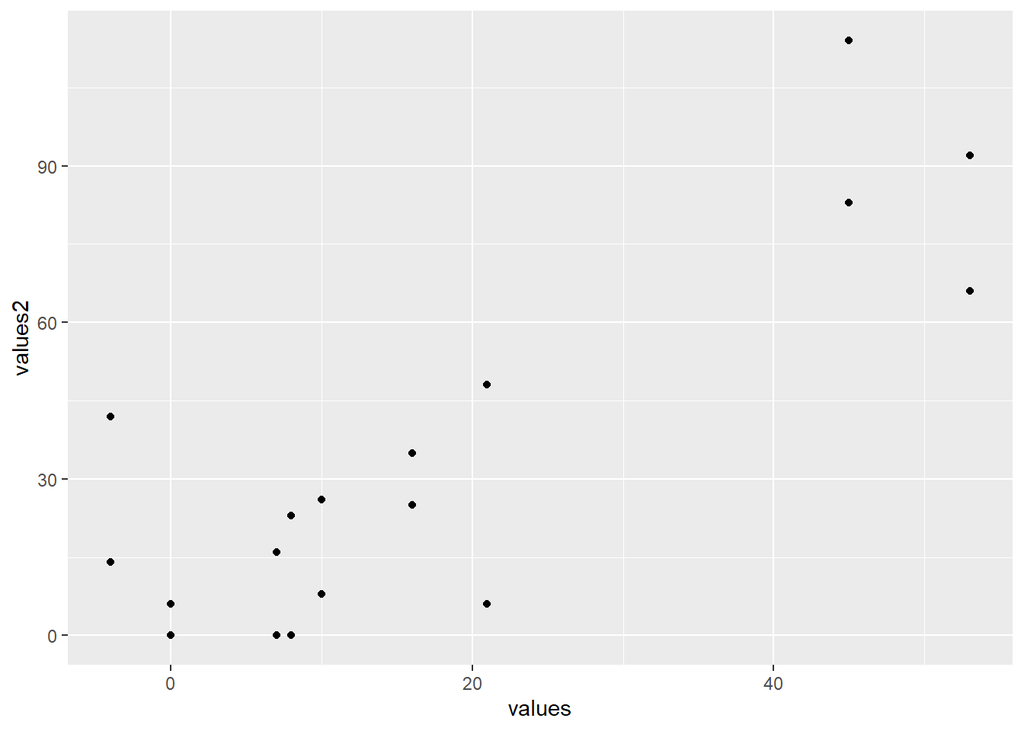

```r
oregon=offClean[(offClean$Opponent_Opponent=='Oregon'),]
oregon=oregon[(oregon$stat=='Receiving_YDS'),]
oklahoma=offClean[(offClean$Opponent_Opponent=='Oklahoma'),]
oklahoma=oklahoma[(oklahoma$stat=='Receiving_YDS'),]

oklahoma = rename(oklahoma, values2 = values)
vs = oregon %>% full_join(oklahoma,by="Name")
ggplot(data = vs, aes(x = values, y = values2)) + geom_point()
```

ISU had a better offense vs Oklahoma due to more yards in those games.

#4. Separate the Hometown column into two columns, namely, the city and the state where the player comes from. Print the first few rows of these two columns.

```r
bioClean
```

```
## # A tibble: 116 x 7
##    Name                 Position       Height Weight Class  Hometown  Highschool
##    <fct>                <chr>           <dbl>  <dbl> <chr>  <chr>     <chr>
##  1 Akers, Landen        Wide Receiver      72    191 Redsh~ Cedar Ra~ Washington
##  2 Allen, Chase         Tight End          79    240 Redsh~ Nixa, Mo. Nixa
##  3 Anderson, Ezeriah    Wide Receiver      77    208 Redsh~ Seffner,~ Armwood
##  4 Antoine Jr. , Michal Defensive Back     72    180 Fresh~ Ft. Laud~ Cardinal ~
##  5 Assalley, Connor     Placekicker        72    195 Redsh~ Napervil~ Central
##  6 Azunna, Arnold       Defensive Back     72    199 Redsh~ Grand Pr~ Lake Ridge
##  7 Bailey, Cordarrius   Defensive End      75    253 Redsh~ Clarksda~ Clarksdale
##  8 Bailey, JaQuan       Defensive End      74    261 Redsh~ Jacksonv~ Raines
##  9 Bailey, Joshua       Defensive Line     74    288 Redsh~ Jacksonv~ Raines
## 10 Bitter, Aidan        Wide Receiver      74    182 Fresh~ Tampa, F~ Steinbren~
## # ... with 106 more rows
```

```r
bioClean = bioClean %>% separate(Hometown, c('City', 'State'), sep=",")
bioClean
```

```
## # A tibble: 116 x 8
##    Name                 Position       Height Weight Class City  State Highschool
##    <fct>                <chr>           <dbl>  <dbl> <chr> <chr> <chr> <chr>
##  1 Akers, Landen        Wide Receiver      72    191 Reds~ Ceda~ " Io~ Washington
##  2 Allen, Chase         Tight End          79    240 Reds~ Nixa  " Mo~ Nixa
##  3 Anderson, Ezeriah    Wide Receiver      77    208 Reds~ Seff~ " Fl~ Armwood
##  4 Antoine Jr. , Michal Defensive Back     72    180 Fres~ Ft. ~ " Fl~ Cardinal ~
##  5 Assalley, Connor     Placekicker        72    195 Reds~ Nape~ " Il~ Central
##  6 Azunna, Arnold       Defensive Back     72    199 Reds~ Gran~ " Te~ Lake Ridge
##  7 Bailey, Cordarrius   Defensive End      75    253 Reds~ Clar~ " Mi~ Clarksdale
##  8 Bailey, JaQuan       Defensive End      74    261 Reds~ Jack~ " Fl~ Raines
##  9 Bailey, Joshua       Defensive Line     74    288 Reds~ Jack~ " Fl~ Raines
## 10 Bitter, Aidan        Wide Receiver      74    182 Fres~ Tampa " Fl~ Steinbren~
## # ... with 106 more rows
```

```r
bioClean = bioClean %>% select(City, State)
print(bioClean, n=3)
```

```
## # A tibble: 116 x 2
##   City         State
##   <chr>        <chr>
## 1 Cedar Rapids " Iowa"
## 2 Nixa         " Mo."
## 3 Seffner      " Fla."
## # ... with 113 more rows
```

#5. How many players are there from each state?

```r
bioClean
```

```
## # A tibble: 116 x 2
##    City           State
##    <chr>          <chr>
##  1 Cedar Rapids   " Iowa"
##  2 Nixa           " Mo."
##  3 Seffner        " Fla."
##  4 Ft. Lauderdale " Fla."
##  5 Naperville     " Ill."
##  6 Grand Prairie  " Texas"
##  7 Clarksdale     " Miss."
##  8 Jacksonville   " Fla."
##  9 Jacksonville   " Fla."
## 10 Tampa          " Fla."
## # ... with 106 more rows
```

```r
bioClean %>% group_by(State) %>% count()
```

```
## # A tibble: 21 x 2
## # Groups:   State [21]
##    State            n
##    <chr>        <int>
##  1 " Ariz."         4
##  2 " Ark."          1
##  3 " Australia"     1
##  4 " Calif."        2
##  5 " Fla."         14
##  6 " Ga."           3
##  7 " Ill."          6
##  8 " Iowa"         42
##  9 " Kan."          4
## 10 " Mich"          1
## # ... with 11 more rows
```

#6. How does the performance of quarterback Brock Purdy relate to the performance of the ISU team? Comment on both the defense and offense.

```r
offClean %>% group_by(Name) %>% filter(Name=="Purdy, Brock") %>% filter(stat=='Passing_CMP') %>%  summarise(Avg_Pass_CMP = mean(values, na.rm = TRUE))
```

```
## # A tibble: 1 x 2
##   Name         Avg_Pass_CMP
##   <fct>               <dbl>
## 1 Purdy, Brock         20.2
```

Offense will directly do better when Purdy’s completion status is high and offense does lower when he is low